# 06. Reproductive Metrics - Hatchling mass

Elliott Schmidt

2024-05-21

# Scenario

Within this chapter developmental plasticity was explored within *Acanthochromis polyacanthus* that were collected from two different regions (i.e., low-latitude, Cairns, and high-latitude, Mackay). Fish were held in common garden experiments at 28.5 C. Reproductive meterics are only relevant to parental fish. Understanding potential differences in reproduction within fish from low- and high-latitude populations will provide basis of where juveniles are starting from.

# Load packages

```r
library(tidyverse) # data manipulation
library(ggpubr) # figure arrangement
library(brms) # Bayesian models
library(StanHeaders)# needed to run Bayesian models
library(rstan) # needed to run Bayesian models
library(standist) # needs to be installed
library(bayesplot) # needed for MCMC diagnostics
library(DHARMa) # model validation
library(ggdist) # partial plots
library(tidybayes) # partial plots
library(broom.mixed) # model investigation
library(emmeans) # pairwise comparisons
library(rstanarm) # pairwise comparisons - need for emmeans
library(car) # for correlation analysis
```

# Set working directory

```r
knitr::opts_knit$set(root.dir=working.dir)
```

# Import data

Note that when making the datasheet, each clutch was designated an ‘experimental_number’ that is associated with which experiment(s) clutches were involved in, therefore when importing the data, we will filter data to give us only clutches that were used in the relevent ‘developmental plasticity experiment’. We are also dropping one clutch that was found only when individuals hatched, meaning we don’t know the clutch size, or hatching success

```r
hmass <- read_delim("import_files/hatchling_size_data_2022_2023.txt",
    delim = "\t", escape_double = FALSE,
    col_types = cols(SL = col_skip(), ...24 = col_skip()),
    trim_ws = TRUE)
```

# Data manipulation

```r
clutch_data <- read_delim("import_files/clutch_data_2022_2023.txt",
    delim = "\t", escape_double = FALSE,
    trim_ws = TRUE) |>
  mutate(PROJECT_CODE = factor(PROJECT_CODE),
         CLUTCH_NUMBER = factor(CLUTCH_NUMBER)) |>
  filter(PROJECT_CODE == "2"|
         PROJECT_CODE == "3"|
         PROJECT_CODE == "6"|
         PROJECT_CODE == "7") |>
  drop_na(EGG_COUNT)
clutch_data2 <- clutch_data |>
  mutate(CLUTCH_NUMBER = as.factor(CLUTCH_NUMBER),
         MALE = factor(MALE),
         FEMALE = factor(FEMALE),
         REGION = factor(REGION),
         POPULATION = factor(POPULATION),
         CLUTCH_ORDER = factor(CLUTCH_ORDER),
         DATE_OF_HATCH = as.Date(DATE_OF_HATCH, format = "%d/%m/%Y"),
         FEMALE_MASS = coalesce(FEMALE_MASS, MALE_MASS))

hmass2 <- hmass |>
  mutate(CLUTCH_NUMBER = factor(CLUTCH_NUMBER),
         MALE = factor(MALE),
         FEMALE = factor(FEMALE),
         REGION = factor(REGION),
         POPULATION = factor(POPULATION),
         CLUTCH_ORDER = factor(CLUTCH_ORDER),
         FEMALE_MASS = coalesce(FEMALE_MASS, MALE_MASS),
         LEVEL = as.factor(case_when(TANK >= 1 & TANK <= 199 ~ 1,
                           TANK >= 200 & TANK <= 299 ~ 2,
                           TANK >= 300 & TANK <= 399 ~ 3,
                           TRUE ~ NA_real_))) |>
  drop_na(MASS) |>
  left_join(select(clutch_data2, c("CLUTCH_NUMBER","EGG_COUNT","HATCHING_SUCCESS","HATCHLINGS")), by="CLUTCH_NUMBER") |>
  drop_na(EGG_COUNT)
```

# Exploratory data analysis

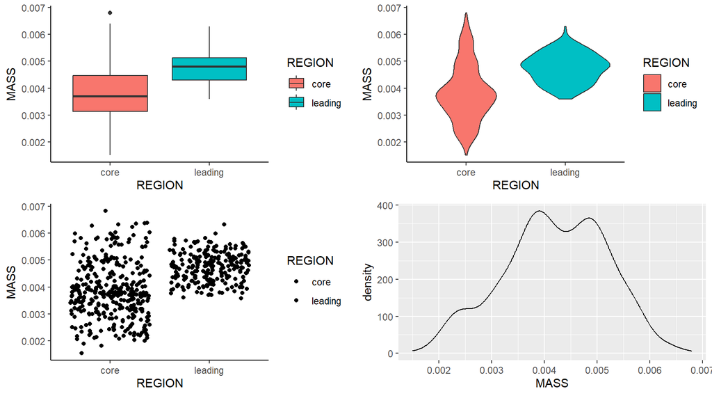

# Prior investigation

```r
hmass2 |>
  group_by(REGION) |>
  summarise(mean(na.omit(MASS)),
            sd(na.omit(MASS)))
```

| REGION | mean(na.omit(MASS)) | sd(na.omit(MASS)) |
| --- | --- | --- |
| core | 0.003833425 | 0.0010324453 |
| leading | 0.004752083 | 0.0005414955 |

# Priors

```r
hmass.priors <- prior(normal(0.00429, 0.001), class="Intercept")
```

# Fit model [random effects]

## null model

```r
f.null.model <- bf(MASS ~ 1,
                   family=gaussian())

null.model <- brm(f.null.model,
                  data=hmass2,
                  prior=hmass.priors,
                  warmup = 500,
                  iter=5000,
                  seed=123,
                  cores=2,
                  save_pars = save_pars(all=TRUE),
                  sample_prior ='yes',
                  chains=2,
                  thin=5,
                  control = list(adapt_delta=0.95))
```

## model1

```r
f.model1 <- bf(MASS ~ 1 + (1| FEMALE),
                   family=gaussian())

model1 <- brm(f.model1,
                  data=hmass2,
                  prior=hmass.priors,
                  warmup = 500,
                  iter=5000,
                  seed=123,
                  cores=2,
                  save_pars = save_pars(all=TRUE),
                  sample_prior ='yes',
                  chains=2,
                  thin=5,
                  control = list(adapt_delta=0.95))
```

## model2

```r
f.model2 <- bf(MASS ~ 1 + (1| FEMALE) + (1| POPULATION),
                   family=gaussian())

model2 <- brm(f.model2,
                  data=hmass2,
                  prior=hmass.priors,
                  warmup = 500,
                  iter=5000,
                  seed=123,
                  cores=2,
                  save_pars = save_pars(all=TRUE),
                  sample_prior ='yes',
                  chains=2,
                  thin=5,
                  control = list(adapt_delta=0.95))
```

## model3

```r
f.model3 <- bf(MASS ~ 1 + (1| FEMALE) + (1| CLUTCH_ORDER),
                   family=gaussian())

model3 <- brm(f.model3,
                  data=hmass2,
                  prior=hmass.priors,
                  warmup = 500,
                  iter=5000,
                  seed=123,
                  cores=2,
                  save_pars = save_pars(all=TRUE),
                  sample_prior ='yes',
                  chains=2,
                  thin=5,
                  control = list(adapt_delta=0.95))
```

## model4

```r
f.model4 <- bf(MASS ~ 1 + (1| FEMALE) + (1| POPULATION) + (1| CLUTCH_ORDER),
                   family=gaussian())

model4 <- brm(f.model4,
                  data=hmass2,
                  prior=hmass.priors,
                  warmup = 500,
                  iter=5000,
                  seed=123,
                  cores=2,
                  save_pars = save_pars(all=TRUE),
                  sample_prior ='yes',
                  chains=2,
                  thin=5,
                  control = list(adapt_delta=0.95))
```

## LOO

```r
LOO(null.model, model1, model2, model3, model4)
```

```
## Output of model 'null.model':
##
## Computed from 1800 by 602 log-likelihood matrix.
##
##          Estimate   SE
## elpd_loo   3315.4 15.2
## p_loo         1.7  0.1
## looic     -6630.8 30.4
## ------
## MCSE of elpd_loo is 0.0.
## MCSE and ESS estimates assume MCMC draws (r_eff in [0.6, 0.9]).
##
## All Pareto k estimates are good (k < 0.69).
## See help('pareto-k-diagnostic') for details.
##
## Output of model 'model1':
##
## Computed from 1800 by 602 log-likelihood matrix.
##
##          Estimate   SE
## elpd_loo   3980.0 20.7
## p_loo        16.8  1.3
## looic     -7960.1 41.4
## ------
## MCSE of elpd_loo is 0.1.
## MCSE and ESS estimates assume MCMC draws (r_eff in [0.7, 1.1]).
##
## All Pareto k estimates are good (k < 0.69).
## See help('pareto-k-diagnostic') for details.
##
## Output of model 'model2':
##
## Computed from 1800 by 602 log-likelihood matrix.
##
##          Estimate   SE
## elpd_loo   3979.9 20.7
## p_loo        16.9  1.3
## looic     -7959.7 41.3
## ------
## MCSE of elpd_loo is 0.1.
```

[output cut: 27 more lines]

```
## looic     -7984.9 42.5
## ------
## MCSE of elpd_loo is 0.1.
## MCSE and ESS estimates assume MCMC draws (r_eff in [0.2, 1.0]).
##
## All Pareto k estimates are good (k < 0.69).
## See help('pareto-k-diagnostic') for details.
##
## Model comparisons:
##            elpd_diff se_diff
## model4        0.0       0.0
## model3       -0.2       0.2
## model1      -12.4       5.3
## model2      -12.6       5.3
## null.model -677.0      23.8
```

# Fit model [fixed factors]

## Collinearity

```r
col.lm <- lm(MASS ~ 1 + REGION +
               scale(FEMALE_MASS, center=TRUE, scale=TRUE) +
               scale(DAYS_IN_TREATMENT, center=TRUE, scale=TRUE) +
               CLUTCH_ORDER,
                data = hmass2)
vif(col.lm)
```

```
##                                                           GVIF Df
## REGION                                                4.014424  1
## scale(FEMALE_MASS, center = TRUE, scale = TRUE)       1.509667  1
## scale(DAYS_IN_TREATMENT, center = TRUE, scale = TRUE) 4.172063  1
## CLUTCH_ORDER                                          6.274878  3
##                                                       GVIF^(1/(2*Df))
## REGION                                                       2.003603
## scale(FEMALE_MASS, center = TRUE, scale = TRUE)              1.228685
## scale(DAYS_IN_TREATMENT, center = TRUE, scale = TRUE)        2.042563
## CLUTCH_ORDER                                                 1.358108
```

## Prior investigation

```r
hmass2 |>
  group_by(REGION) |>
  summarise(mean(na.omit(MASS)),
            sd(na.omit(MASS)))
```

| REGION | mean(na.omit(MASS)) | sd(na.omit(MASS)) |
| --- | --- | --- |
| core | 0.003833425 | 0.0010324453 |
| leading | 0.004752083 | 0.0005414955 |

## Priors

```r
mass.priors <- prior(normal(0.0043, 0.0001), class="Intercept") +
  prior(normal(0, 0.0005), class="b") +
  prior(student_t(3, 0, 0.0015), class = "sigma")
```

## Models

### Model1.1

#### Model1.1

```r
f.model1.1 <- bf(MASS ~ 1 + REGION +
                   scale(FEMALE_MASS, center = TRUE, scale = TRUE) +
                   (1| FEMALE) + (1| POPULATION) + (1| CLUTCH_ORDER),
                 family=gaussian())

model1.1 <- brm(f.model1.1,
                data =hmass2,
                prior =mass.priors,
                warmup = 500,
                  iter = 5000,
                  seed=123,
                  cores=2,
                  save_pars = save_pars(all=TRUE),
                  sample_prior = "yes",
                  chains = 2,
                  thin = 10,
                  control = list(adapt_delta=0.95))
saveRDS(model1.1, file="./06.Hatchling_size_files/model1.1.RDS")
```

#### DHARMa

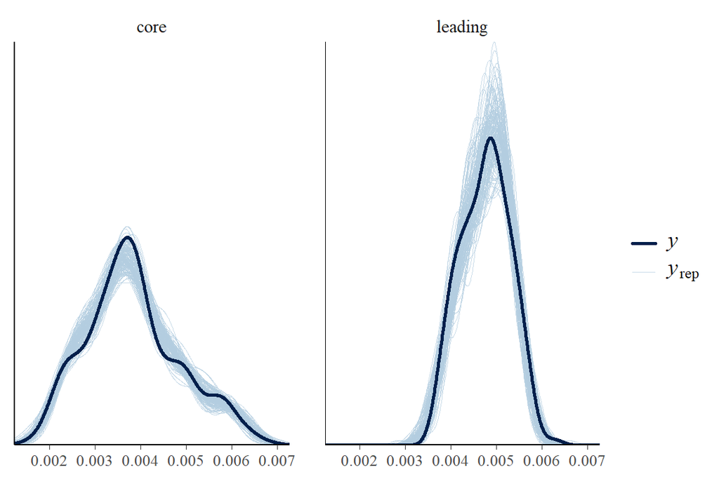

```r
#--- distribution check ---#
pp_check(model1.1, type = 'dens_overlay_grouped', ndraws=150, group="REGION")
```

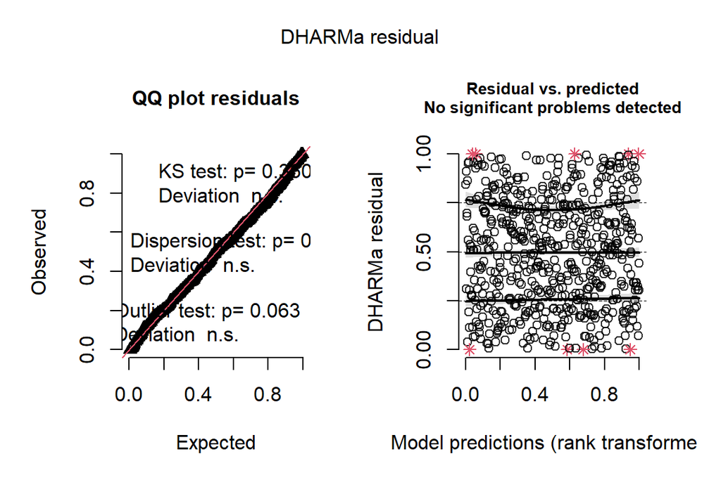

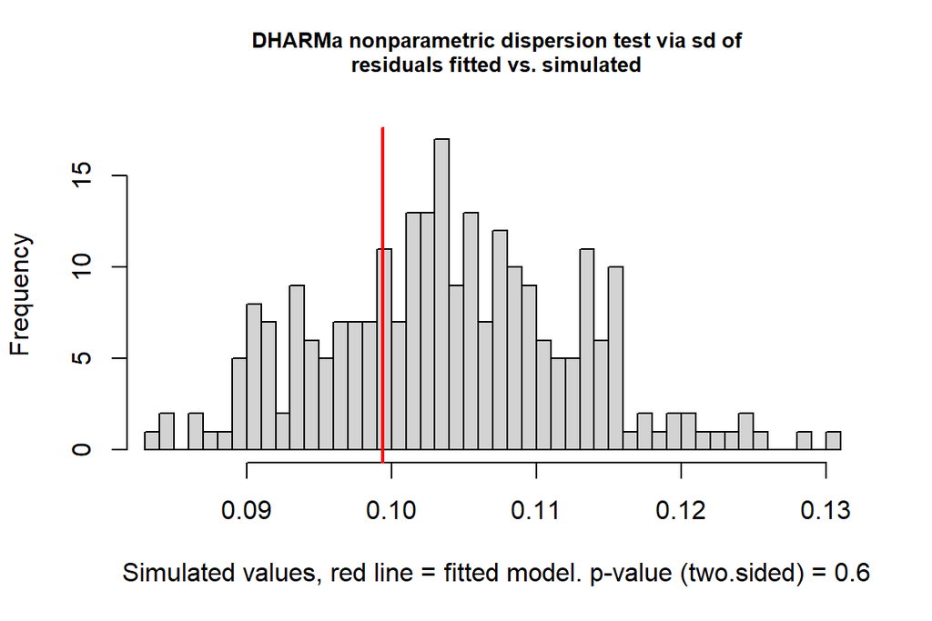

```
##
##  DHARMa nonparametric dispersion test via sd of residuals fitted vs.
##  simulated
##
## data:  simulationOutput
## dispersion = 0.9562, p-value = 0.6
## alternative hypothesis: two.sided
```

```r
#--- DHARMa checks ---#
preds <- posterior_predict(model1.1 , ndraws=250, summary=FALSE)
model1.1_resids <- createDHARMa(simulatedResponse = t(preds),
                              observedResponse = hmass2$MASS,
                              fittedPredictedResponse = apply(preds, 2, mean),
                              integerResponse = 'student')
plot(model1.1_resids) ; testDispersion(model1.1_resids)
```

#### MCMC Diagnostics

```r
stan_trace(model1.1$fit)
```

```
## 'pars' not specified. Showing first 10 parameters by default.
```

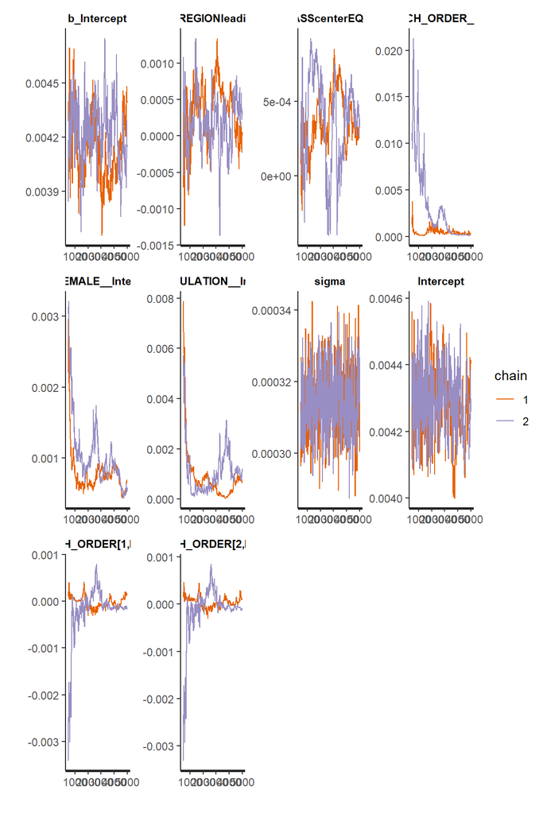

```r
stan_ac(model1.1$fit)
```

```
## 'pars' not specified. Showing first 10 parameters by default.
```

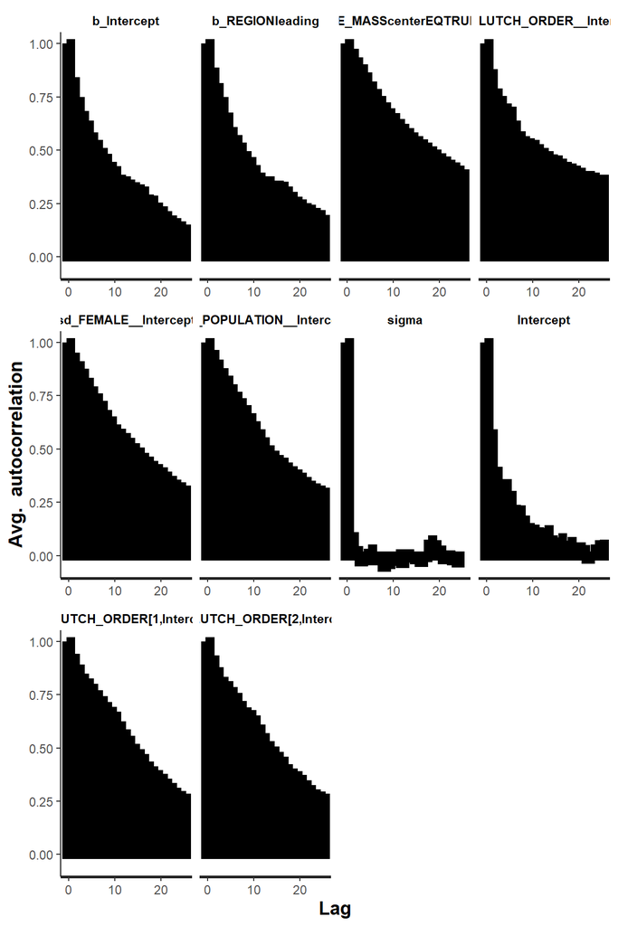

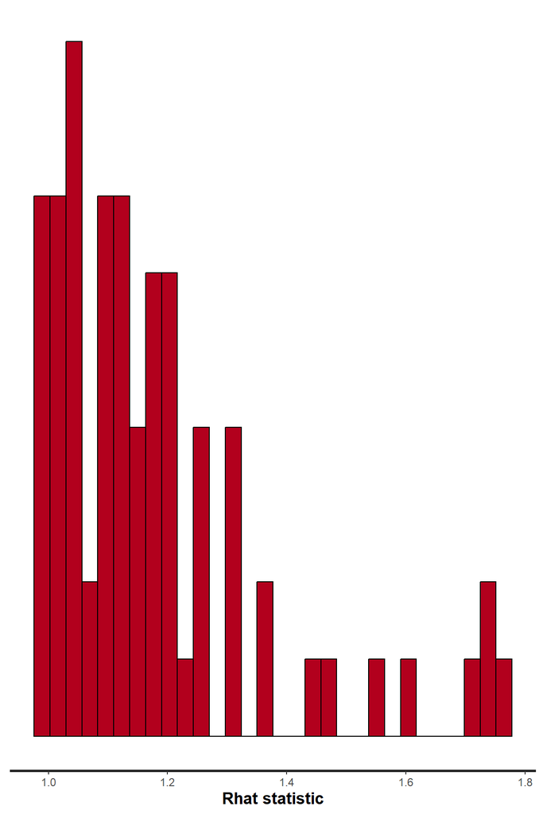

```r
stan_rhat(model1.1$fit)
```

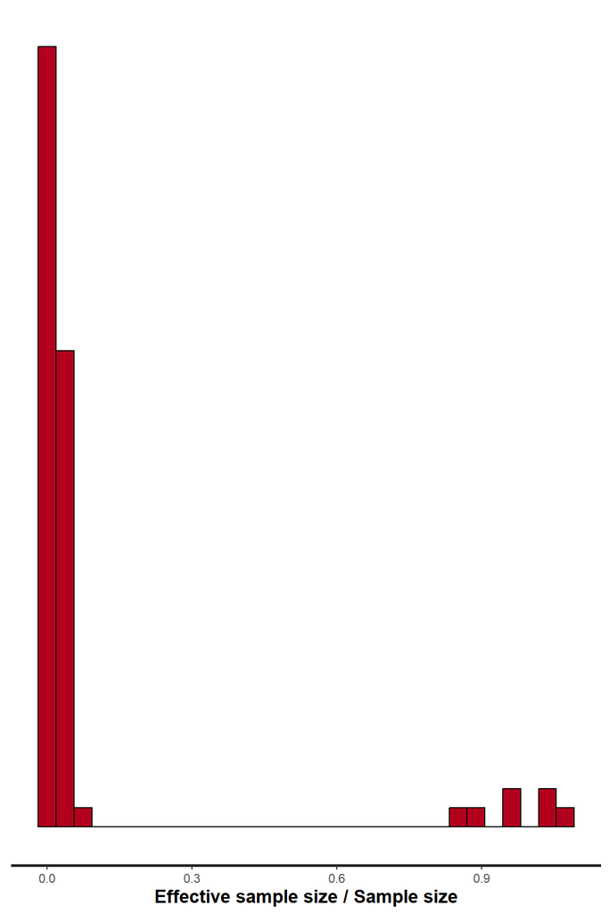

```r
stan_ess(model1.1$fit)
```

```r
stan_dens(model1.1$fit, separate_chains = TRUE)
```

```
## 'pars' not specified. Showing first 10 parameters by default.
```

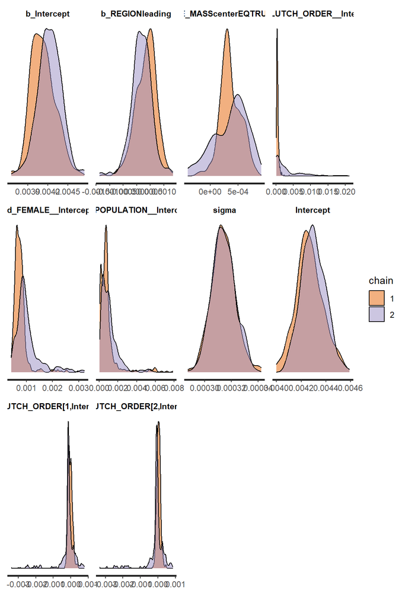

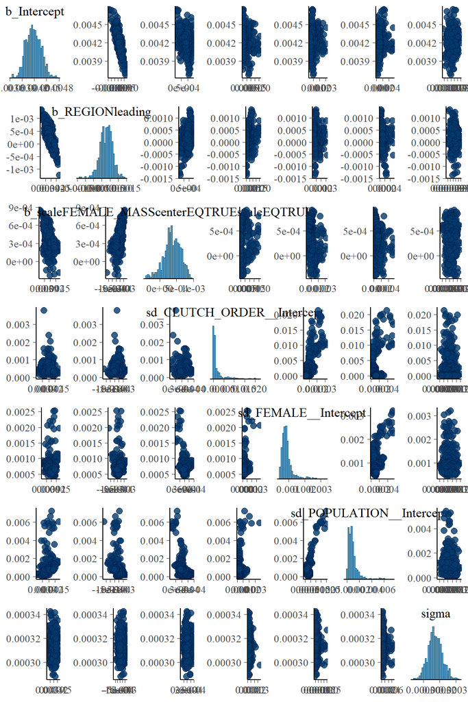

```r
pairs(model1.1)
```

### Model1.2

#### model1.2

```r
f.model1.2 <- bf(MASS ~ 1 + REGION +
                   scale(FEMALE_MASS, center = TRUE, scale = TRUE) +
                   (1| FEMALE) + (1| POPULATION) + (1| CLUTCH_ORDER),
                 family=gaussian())

model1.2 <- brm(f.model1.1,
                data =hmass2,
                prior =mass.priors,
                warmup = 1000,
                  iter = 10000,
                  seed=123,
                  cores=2,
                  save_pars = save_pars(all=TRUE),
                  sample_prior = "yes",
                  chains = 2,
                  thin = 20,
                  control = list(adapt_delta=0.95, max_treedepth=15))
saveRDS(model1.2, file="./06.Hatchling_size_files/model1.2.RDS")
```

#### DHARMa

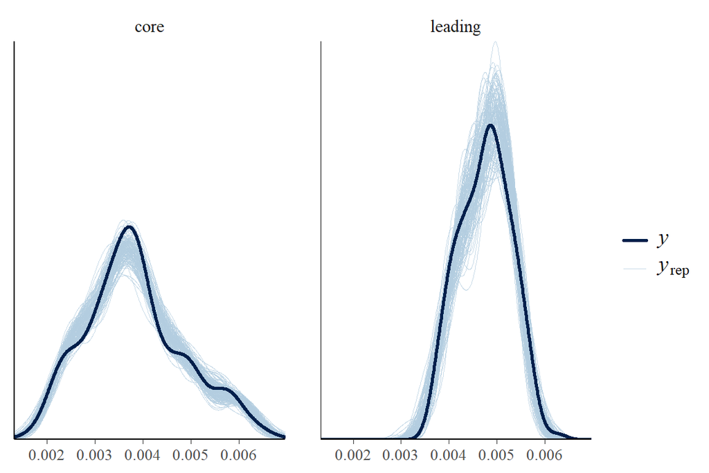

```r
#--- distribution check ---#
pp_check(model1.2, type = 'dens_overlay_grouped', ndraws=150, group="REGION")
```

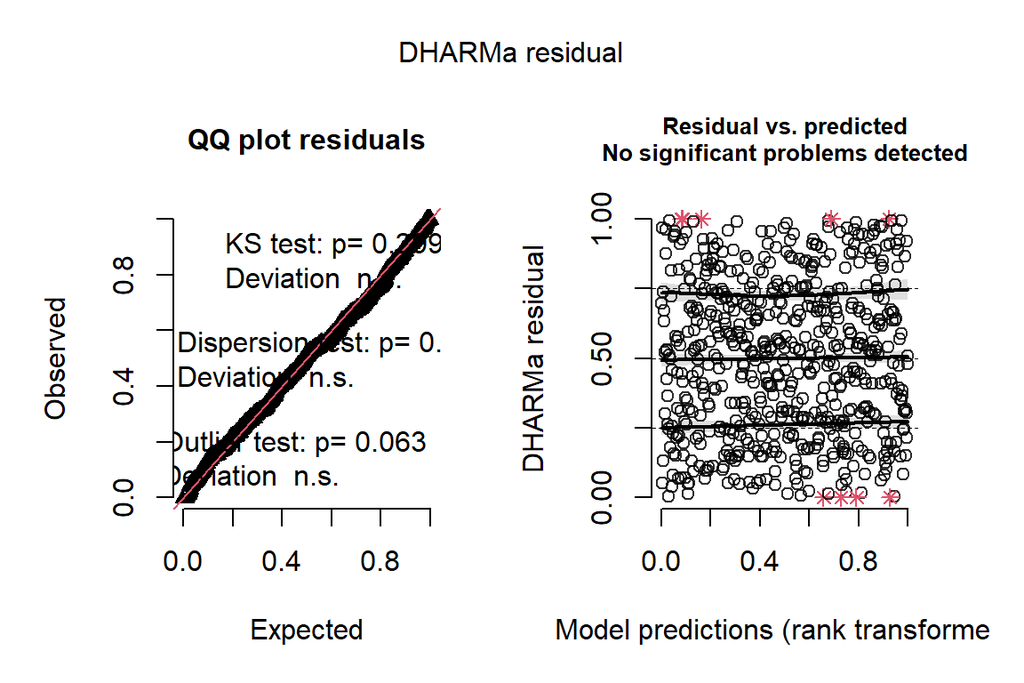

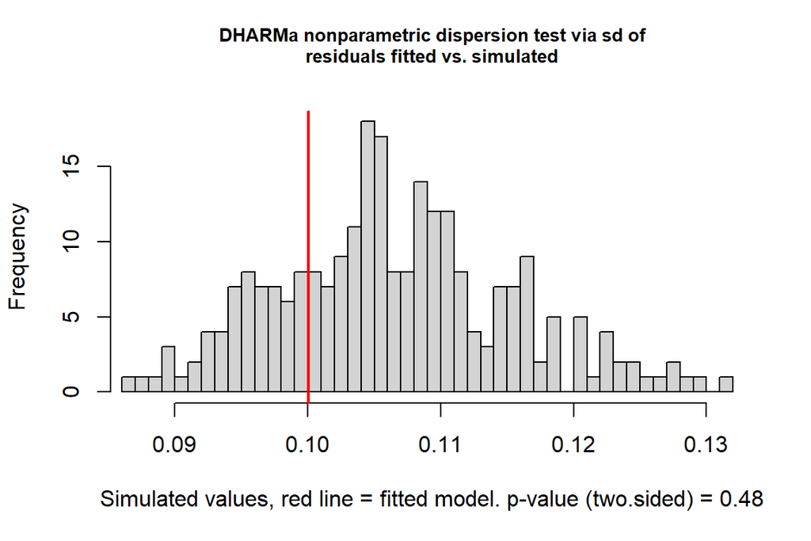

```
##
##  DHARMa nonparametric dispersion test via sd of residuals fitted vs.
##  simulated
##
## data:  simulationOutput
## dispersion = 0.93988, p-value = 0.48
## alternative hypothesis: two.sided
```

```r
#--- DHARMa checks ---#
preds <- posterior_predict(model1.2 , ndraws=250, summary=FALSE)
model1.2_resids <- createDHARMa(simulatedResponse = t(preds),
                              observedResponse = hmass2$MASS,
                              fittedPredictedResponse = apply(preds, 2, mean),
                              integerResponse = 'student')
plot(model1.2_resids) ; testDispersion(model1.2_resids)
```

#### MCMC Diagnostics

```r
stan_trace(model1.2$fit)
```

```
## 'pars' not specified. Showing first 10 parameters by default.
```

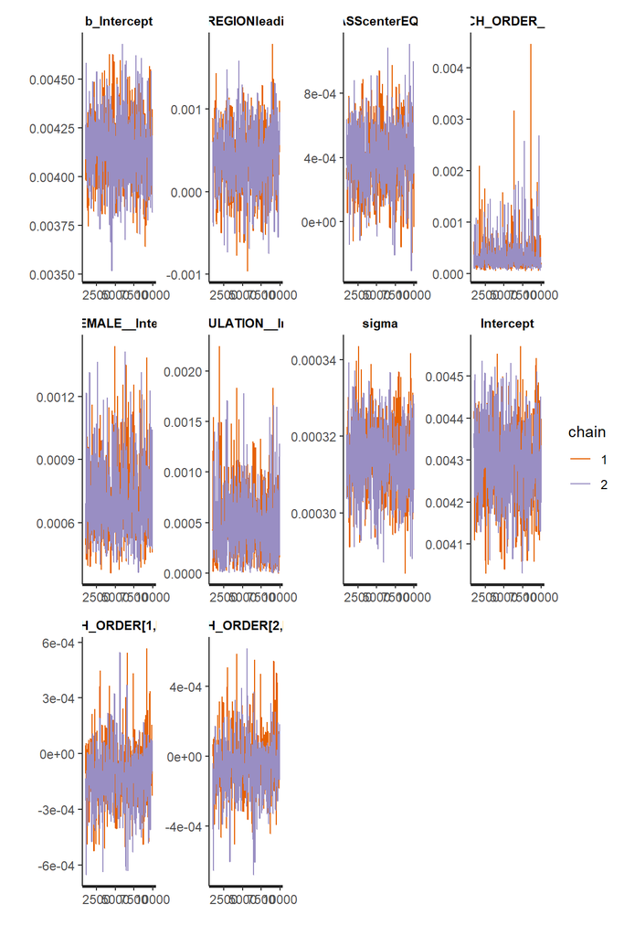

```r
stan_ac(model1.2$fit)
```

```
## 'pars' not specified. Showing first 10 parameters by default.
```

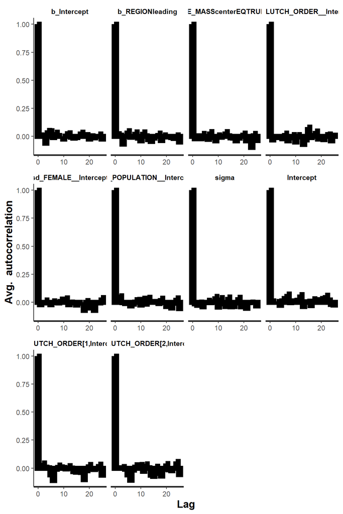

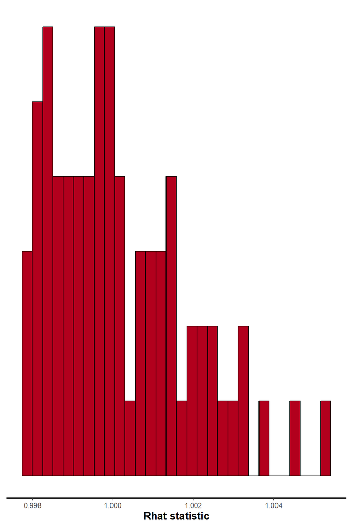

```r
stan_rhat(model1.2$fit)
```

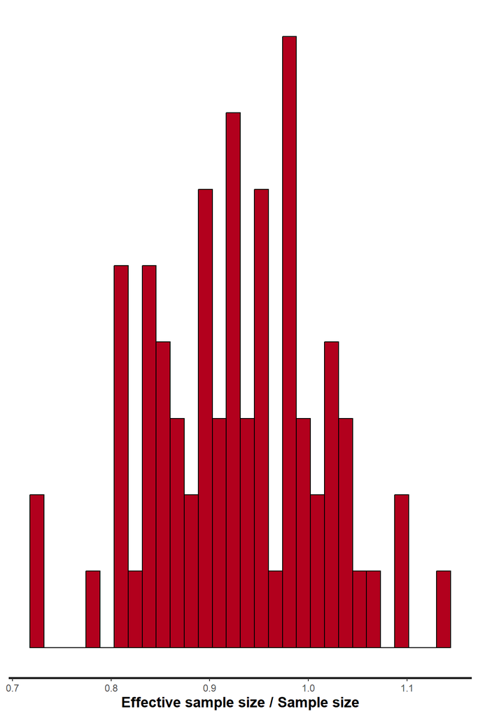

```r
stan_ess(model1.2$fit)
```

```r
stan_dens(model1.2$fit, separate_chains = TRUE)
```

```
## 'pars' not specified. Showing first 10 parameters by default.
```

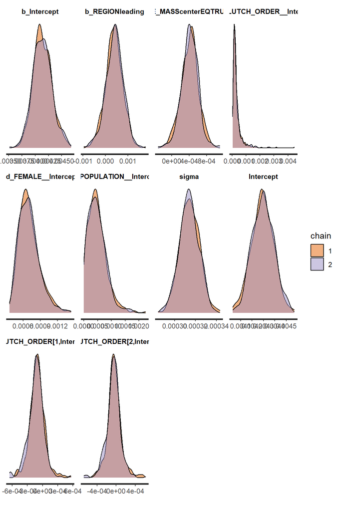

### Model1.3

```r
mass.priors.gamma <- prior(normal(0.0043, 0.0001), class="Intercept") +
  prior(normal(0, 0.0005), class="b")
```

#### model1.3

```r
f.model1.3 <- bf(MASS ~ 1 + REGION +
                   scale(FEMALE_MASS, center = TRUE, scale = TRUE) +
                   (1| FEMALE) + (1| POPULATION) + (1| CLUTCH_ORDER),
                 family=Gamma(link="log"))

model1.3 <- brm(f.model1.3,
                data =hmass2,
                prior =mass.priors.gamma,
                warmup = 500,
                  iter = 5000,
                  seed=123,
                  cores=2,
                  save_pars = save_pars(all=TRUE),
                  sample_prior = "yes",
                  chains = 2,
                  thin = 10,
                  control = list(adapt_delta=0.95))
saveRDS(model1.3, file="./06.Hatchling_size_files/model1.3.RDS")
```

#### DHARMa

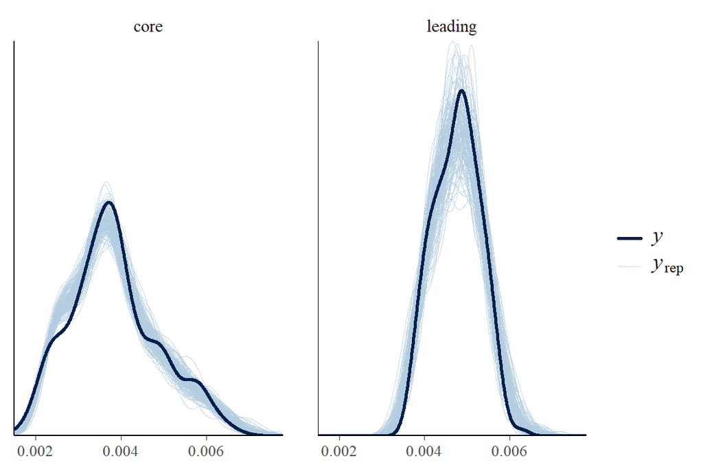

```r
#--- distribution check ---#
pp_check(model1.3, type = 'dens_overlay_grouped', ndraws=150, group="REGION")
```

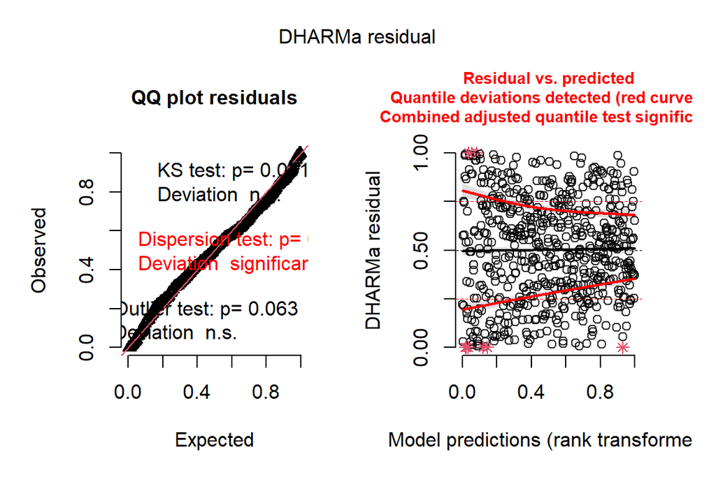

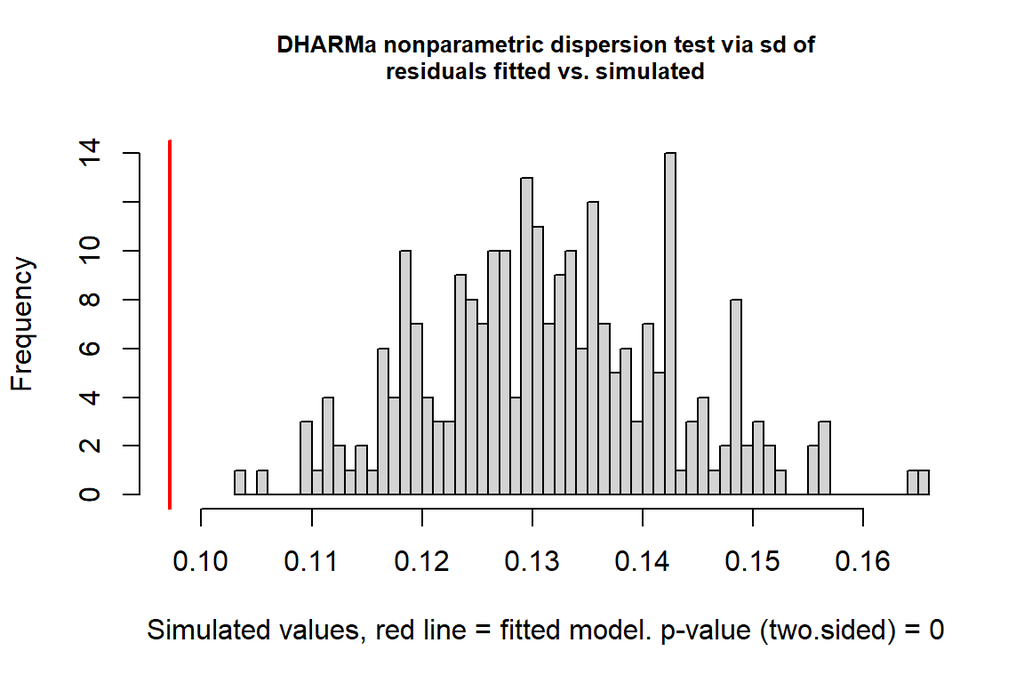

```
##
##  DHARMa nonparametric dispersion test via sd of residuals fitted vs.
##  simulated
##
## data:  simulationOutput
## dispersion = 0.73782, p-value < 2.2e-16
## alternative hypothesis: two.sided
```

```r
#--- DHARMa checks ---#
preds <- posterior_predict(model1.3 , ndraws=250, summary=FALSE)
model1.3_resids <- createDHARMa(simulatedResponse = t(preds),
                              observedResponse = hmass2$MASS,
                              fittedPredictedResponse = apply(preds, 2, mean),
                              integerResponse = 'student')
plot(model1.3_resids) ; testDispersion(model1.3_resids)
```

#### MCMC Diagnostics

```r
stan_trace(model1.3$fit)
```

```
## 'pars' not specified. Showing first 10 parameters by default.
```

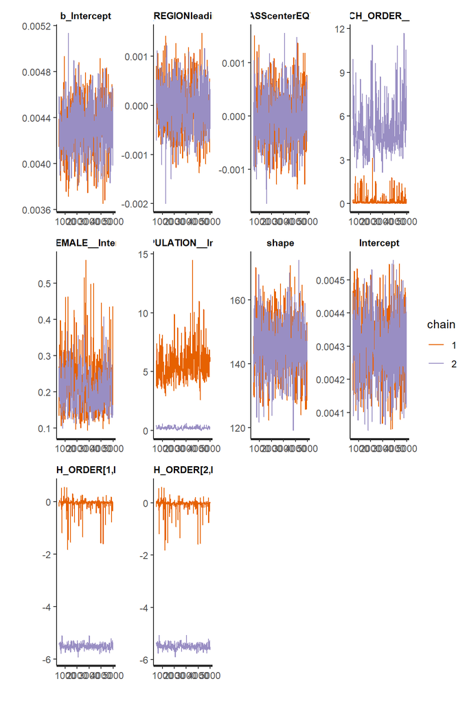

```r
stan_ac(model1.3$fit)
```

```
## 'pars' not specified. Showing first 10 parameters by default.
```

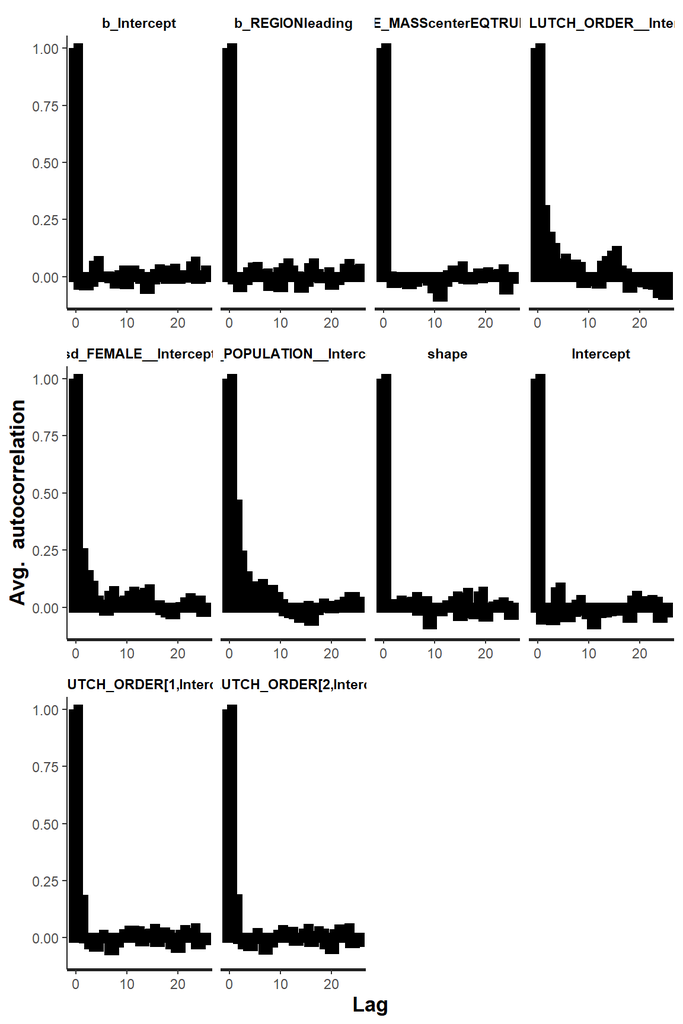

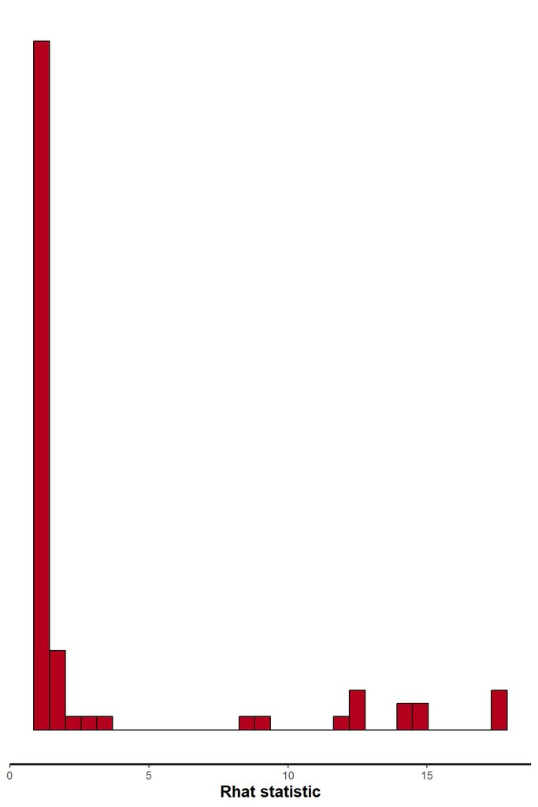

```r
stan_rhat(model1.3$fit)
```

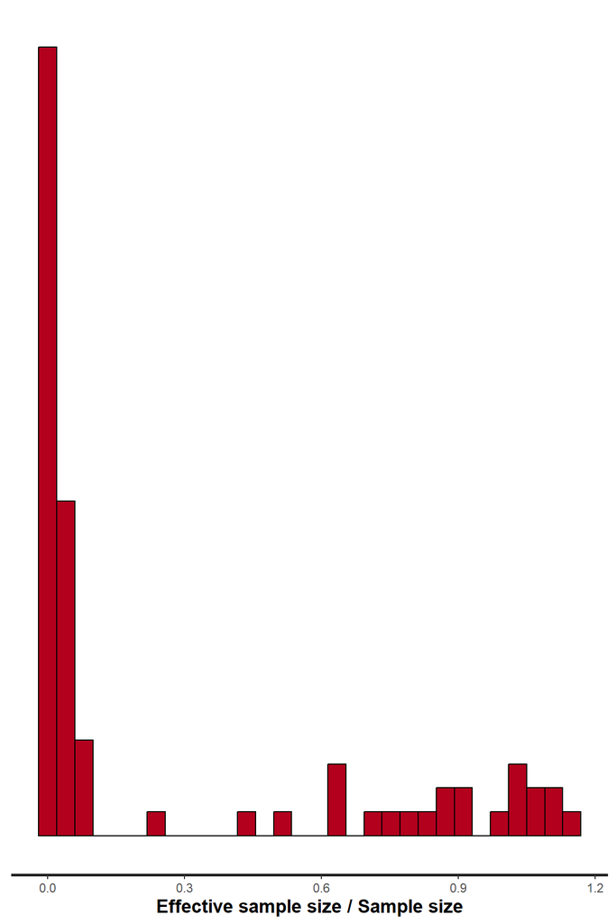

```r
stan_ess(model1.3$fit)
```

```r
stan_dens(model1.3$fit, separate_chains = TRUE)
```

```
## 'pars' not specified. Showing first 10 parameters by default.
```

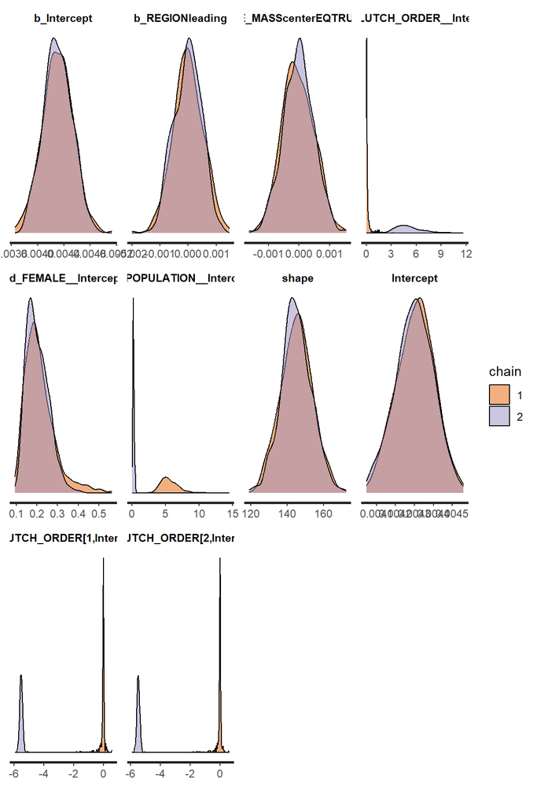

# partial plots

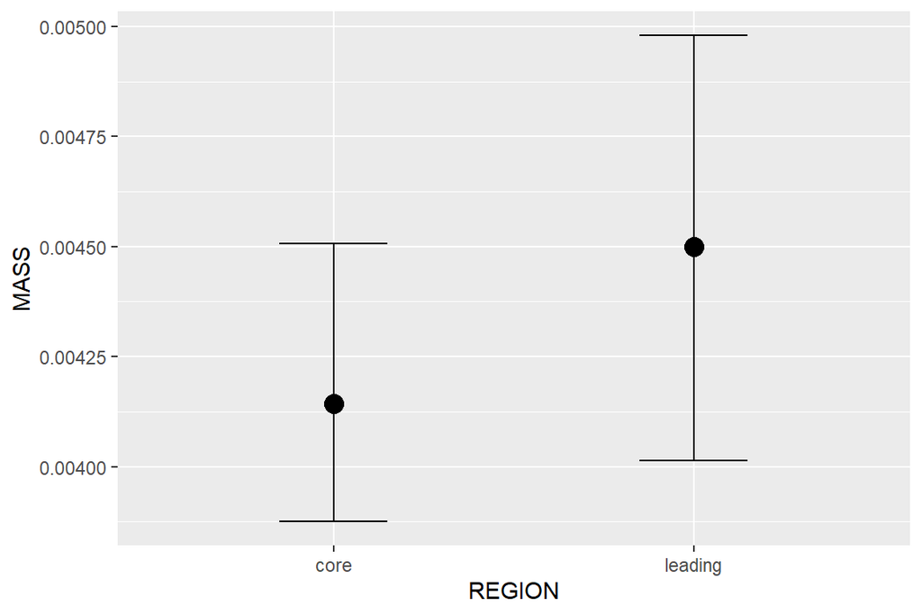

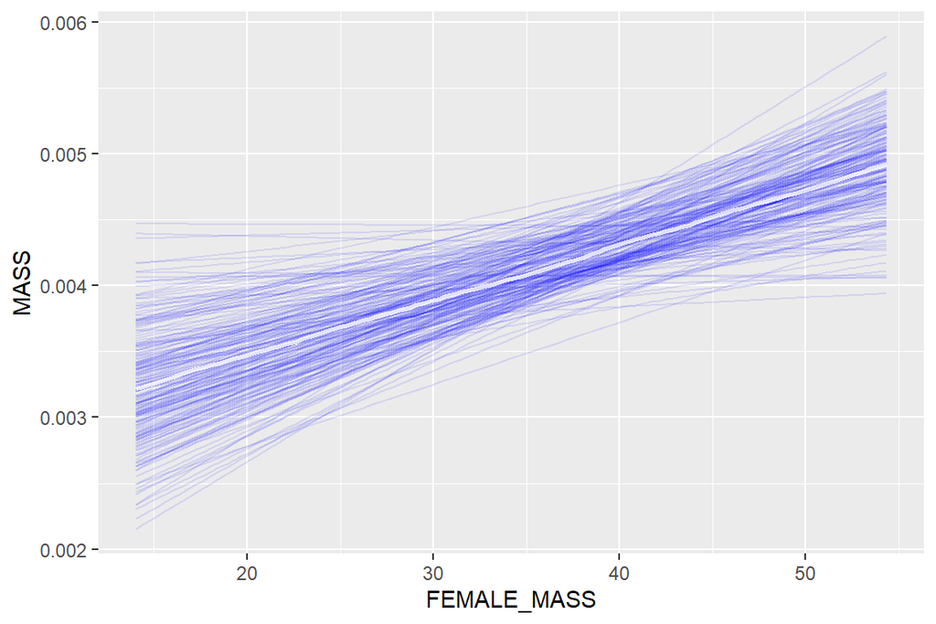

```r
model1.2 |> conditional_effects(spaghetti = TRUE, ndraws=200)
```

# Model investigation

## summary

```r
summary(model1.2)
```

```
##  Family: gaussian
##   Links: mu = identity; sigma = identity
## Formula: MASS ~ 1 + REGION + scale(FEMALE_MASS, center = TRUE, scale = TRUE) + (1 | FEMALE) + (1 | POPULATION) + (1 | CLUTCH_ORDER)
##    Data: hmass2 (Number of observations: 602)
##   Draws: 2 chains, each with iter = 10000; warmup = 1000; thin = 20;
##          total post-warmup draws = 900
##
## Group-Level Effects:
## ~CLUTCH_ORDER (Number of levels: 4)
##               Estimate Est.Error l-95% CI u-95% CI Rhat Bulk_ESS Tail_ESS
## sd(Intercept)     0.00      0.00     0.00     0.00 1.00      919      877
##
## ~FEMALE (Number of levels: 16)
##               Estimate Est.Error l-95% CI u-95% CI Rhat Bulk_ESS Tail_ESS
## sd(Intercept)     0.00      0.00     0.00     0.00 1.00      902      803
##
## ~POPULATION (Number of levels: 9)
##               Estimate Est.Error l-95% CI u-95% CI Rhat Bulk_ESS Tail_ESS
## sd(Intercept)     0.00      0.00     0.00     0.00 1.00      714      744
##
## Population-Level Effects:
##                                         Estimate Est.Error l-95% CI u-95% CI
## Intercept                                   0.00      0.00     0.00     0.00
## REGIONleading                               0.00      0.00    -0.00     0.00
## scaleFEMALE_MASScenterEQTRUEscaleEQTRUE     0.00      0.00     0.00     0.00
##                                         Rhat Bulk_ESS Tail_ESS
## Intercept                               1.00      876      918
## REGIONleading                           1.00      862      768
## scaleFEMALE_MASScenterEQTRUEscaleEQTRUE 1.00      927      875
##
## Family Specific Parameters:
##       Estimate Est.Error l-95% CI u-95% CI Rhat Bulk_ESS Tail_ESS
## sigma     0.00      0.00     0.00     0.00 1.00      929      647
##
## Draws were sampled using sampling(NUTS). For each parameter, Bulk_ESS
## and Tail_ESS are effective sample size measures, and Rhat is the potential
## scale reduction factor on split chains (at convergence, Rhat = 1).
```

## R2

```r
model1.2 |> bayes_R2(summary = FALSE) |> median_hdci()
```

| y | ymin | ymax | .width | .point | .interval |
| --- | --- | --- | --- | --- | --- |
| 0.8977757 | 0.8928655 | 0.9029917 | 0.95 | median | hdci |

## tidyMCMC

```r
tidyMCMC(model1.2, estimate.method='median', conf.int=TRUE, conf.method='HPDinterval')
```

| term | estimate | std.error | conf.low | conf.high |
| --- | --- | --- | --- | --- |
| b_Intercept | 4.128150e-03 | 1.768704e-04 | 3.805028e-03 | 4.511583e-03 |
| b_REGIONleading | 4.002096e-04 | 3.841791e-04 | -3.777477e-04 | 1.117690e-03 |
| b_scaleFEMALE_MASScenterEQTRUEscaleEQTRUE | 4.247696e-04 | 1.951257e-04 | 2.047516e-05 | 7.997516e-04 |
| sd_CLUTCH_ORDER__Intercept | 2.370425e-04 | 3.446367e-04 | 5.884464e-05 | 9.606373e-04 |
| sd_FEMALE__Intercept | 6.864339e-04 | 1.797620e-04 | 4.020019e-04 | 1.070543e-03 |
| sd_POPULATION__Intercept | 4.469429e-04 | 3.290679e-04 | 3.107622e-06 | 1.067079e-03 |
| sigma | 3.141174e-04 | 9.254803e-06 | 2.953905e-04 | 3.309252e-04 |
| Intercept | 4.292329e-03 | 9.460448e-05 | 4.127567e-03 | 4.494080e-03 |
| r_CLUTCH_ORDER[1,Intercept] | -1.138298e-04 | 1.530275e-04 | -4.094114e-04 | 2.141487e-04 |
| r_CLUTCH_ORDER[2,Intercept] | -4.748456e-05 | 1.515904e-04 | -3.523878e-04 | 2.595773e-04 |

[output cut: 63 more lines]

## gather draws

```r
#model1.2 |> get_variables()
model1.2 |> gather_draws(`b_.*|sigma`, regex =TRUE) |>
  median_hdci()
```

| .variable | .value | .lower | .upper | .width | .point | .interval |
| --- | --- | --- | --- | --- | --- | --- |
| b_Intercept | 0.0041281504 | 3.805028e-03 | 0.0045115832 | 0.95 | median | hdci |
| b_REGIONleading | 0.0004002096 | -3.777478e-04 | 0.0011176900 | 0.95 | median | hdci |
| b_scaleFEMALE_MASScenterEQTRUEscaleEQTRUE | 0.0004247696 | 2.047517e-05 | 0.0007997516 | 0.95 | median | hdci |
| sigma | 0.0003141174 | 2.957456e-04 | 0.0003313208 | 0.95 | median | hdci |

## bayesplot

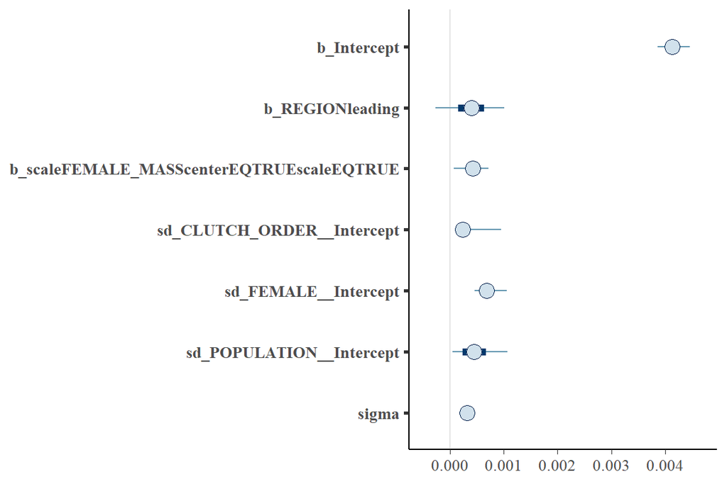

```r
model1.2 |> mcmc_plot(type='intervals')
```

## emmeans - pariwise

```r
model1.2 |> emmeans(pairwise ~ REGION, type="response") |> pairs() |> summary()
```

|  | contrast | estimate | lower.HPD | upper.HPD |
| --- | --- | --- | --- | --- |
| 1 | core - leading | -0.0004002096 | -0.00111769 | 0.0003777477 |

```r
model1.2 |> emmeans(pairwise ~ REGION, type="response")
```

```
## $emmeans
##  REGION   emmean lower.HPD upper.HPD
##  core    0.00413   0.00381   0.00451
##  leading 0.00453   0.00405   0.00504
##
## Point estimate displayed: median
## HPD interval probability: 0.95
##
## $contrasts
##  contrast       estimate lower.HPD upper.HPD
##  core - leading   -4e-04  -0.00112  0.000378
##
## Point estimate displayed: median
## HPD interval probability: 0.95
```

## probabilities

```r
mtsqst <- model1.2 |> emmeans(pairwise ~ REGION)
mtsqrt1 <- mtsqst$contrasts |> gather_emmeans_draws()
mtsqrt1 %>% group_by(contrast) %>% dplyr::summarise(Prob = sum(.value>0)/n())
```

| contrast | Prob |
| --- | --- |
| core - leading | 0.1522222 |

# Summary plot

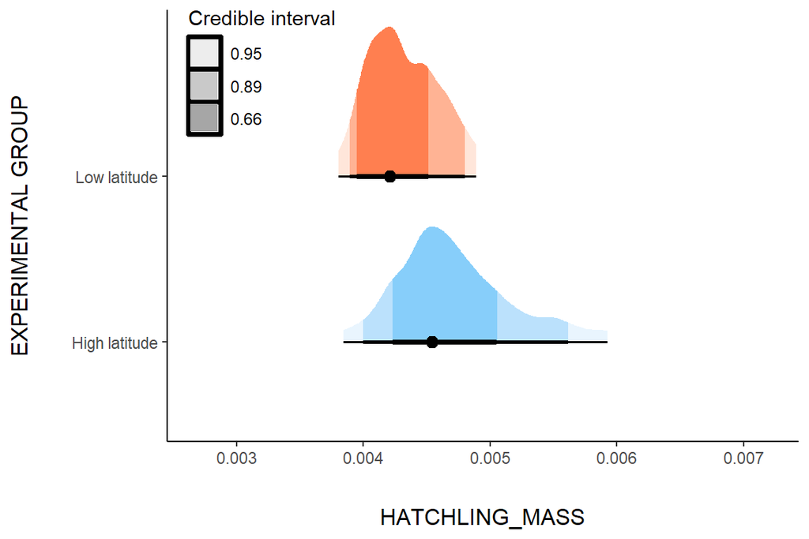

```r
var <- get_variables(model1.2)
var1 <- get_variables(model1.2)[c(1:2)]

int_draws_spread <- model1.2 |> spread_draws(!!!syms(var1))

int_draws_spread2 <- int_draws_spread |>
  gather_draws(b_Intercept, b_REGIONleading) |>
  left_join(int_draws_spread, by = c(".chain",".iteration",".draw"))


int_draws <- int_draws_spread2 |>
  mutate(RCore = case_when(`.variable` == 'b_Intercept' ~
                             `.value`,
                           `.variable` != 'b_Intercept' ~
                             `.value` + b_Intercept),

         RLeading = case_when(`.variable` == 'b_Intercept' ~
                           `.value` + b_REGIONleading,
                         `.variable` == 'b_REGIONleading' ~
                           `.value` + b_Intercept + `b_REGIONleading`))

int_draws_plotting <- int_draws |>
  pivot_longer(cols = starts_with("R"),
               names_to = "REGION",
               values_to = "HATCHLING_MASS") |>
  transmute(LATITUDE = case_when(`.variable` == "b_Intercept" ~ "Low latitude",
                                 `.variable` == "b_REGIONleading" ~ "High latitude"),
            HATCHLING_MASS = HATCHLING_MASS,
            LATITUDE_B = LATITUDE,
            chain = `.chain`,
            iteration = `.iteration`,
            draw_n = `.draw`)

hatchling.size.plot <- int_draws_plotting |>
  ggplot(aes(x=LATITUDE, y=HATCHLING_MASS)) +
  #geom_hline(yintercept = 0, linetype="dashed", linewidth=1, color="grey58", alpha=0.8) +
  stat_halfeye(aes(fill = LATITUDE, fill_ramp = after_stat(level)),
               point_interval = mode_hdci,
               .width = c(.66, .89, .95)) +
  scale_fill_ramp_discrete(na.translate=FALSE,
                           labels =c("0.95","0.89","0.66"),
                           name = "Credible interval") +
  scale_fill_manual(values = c("lightskyblue","coral"))+
  #scale_y_continuous(limits=c(0,2), breaks = seq(0,2, .5))+
  ylab("HATCHLING_MASS") + xlab("EXPERIMENTAL GROUP") +
  scale_x_discrete(labels = c("Low latitude" = paste0("Low latitude"),
                              "High latitude" = paste0("High latitude"))) +
  #annotate("text", x=6.8,y=1.4, label = paste0(round(mean(growth3$MASS), 2)," (mm)"), color="grey58") +
  coord_flip() +
  theme_classic() +
  guides(fill = "none") +
  theme(legend.position = c(.15,.86),
        axis.title.y = element_text(margin = margin(r =0.3, unit = "in"), size = 12),
        axis.title.x = element_text(margin = margin(t = 0.3, unit="in"), size =12),
        legend.key = element_rect(color="black", size=1.25),
        legend.background = element_rect(fill = alpha("blue", 0))); hatchling.size.plot
```